# Housing Response

Me

4/25/2018

## Student Housing Costs

In response to Stephanie’s freshman dilemma, the following research has been proposed. All student housing (that is approved for women) has had it’s price, location, and amount of people analyzed to see which option would be the best for Stephanie.

## cost

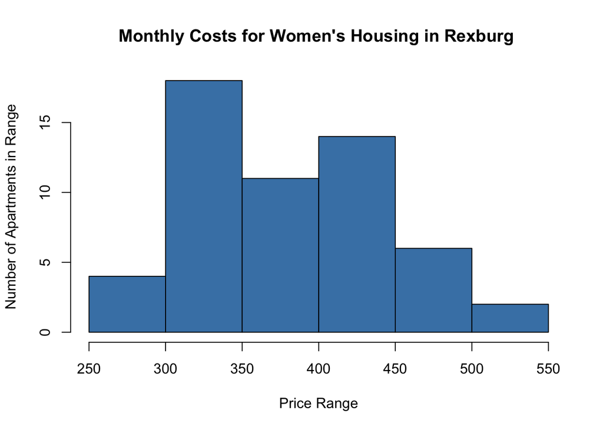

# Cost Analysis

As we can see from the graph above, there are 4 apartment complexes that are below or at the $300 a month mark. They are (from least to greatest): Brooklyn Apartments at $290, Hill’s College Ave Apts at $293.33, Davenport Apartments at $298.33 and finally Aspen Village - Women at exactly $300.